# Reproducible Research: Peer Assessment 1

## Loading and preprocessing the data

```r
if(!file.exists('activity.csv')){
    unzip('activity.zip')
}
activities <- read.csv("activity.csv",
                        header =TRUE,
                        na.strings = "NA")
```

## What is mean total number of steps taken per day?

### 1. Calculate the total number of steps taken per day

```r
stepsPerDay <- tapply(activities$steps,
                      activities$date,
                      sum,
                      na.rm=TRUE)
```

### 2. Make a histogram of the total number of steps taken each day

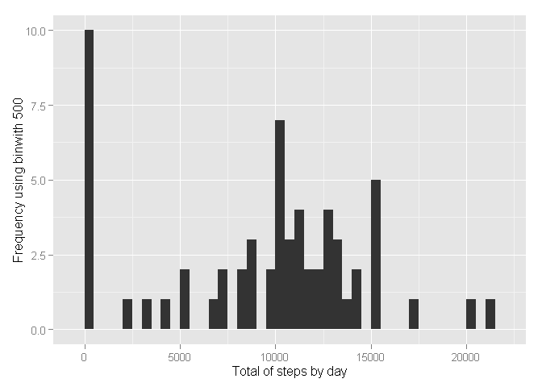

```r
qplot(stepsPerDay, xlab='Total of steps by day', ylab='Frequency using binwith 500', binwidth=500)
```

### 3. Calculate and report the mean and median of the total number of steps taken per day

```r
stepsperDayMean <- mean(stepsPerDay)
stepsPerDayMedian <- median(stepsPerDay)
```

- Mean of Step per day : 9354.2295082
- Median of Step per day: 10395

## What is the average daily activity pattern?

```r
averageStepsPerInterval <- aggregate(x=list(meanSteps=activities$steps),
                                             by=list(interval=activities$interval),
                                             FUN=mean,
                                             na.rm=TRUE)
```

### 3. Make a time series plot (i.e. type = “l”) of the 5-minute interval (x-axis) and the average number of steps taken, averaged across all days (y-axis)

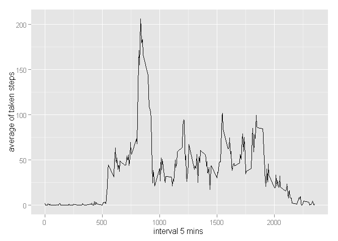

```r
ggplot(data=averageStepsPerInterval,
            aes(x=interval,
                y=meanSteps)) + geom_line() + xlab("interval 5 mins ") +
       ylab("average of taken steps")
```

### 4. Which 5-minute interval, on average across all the days in the dataset, contains the maximum number of steps?

```r
maxSteps <- which.max(averageStepsPerInterval$meanSteps)
internvalmaxSteps <-  gsub("([0-9]{1,2})([0-9]{2})", "\\1:\\2", averageStepsPerInterval[maxSteps,'interval'])
```

- Max steps are in interval : 8:35

## Imputing missing values

### 1. Calculate and report the total number of missing values in the dataset (i.e. the total number of rows with NAs)

```r
countMissingValues <- length(which(is.na(activities$steps)))
```

- Number of values missing: 2304

### 3. Create a new dataset that is equal to the original dataset but with the missing data filled in.

```r
activitiesEnriched <- activities
activitiesEnriched$steps <- impute(activities$steps, fun=mean)
```

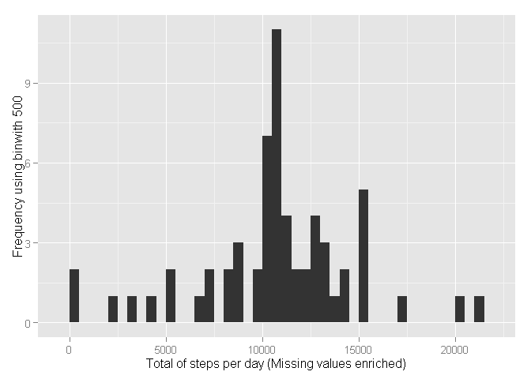

```r
stepsPerDayEnriched <- tapply(activitiesEnriched$steps, activitiesEnriched$date, sum)

qplot(stepsPerDayEnriched,
      xlab='Total of steps per day (Missing values enriched)',
      ylab='Frequency using binwith 500',
      binwidth=500)
```

## Are there differences in activity patterns between weekdays and weekends

### 1. Create a new factor variable in the dataset with two levels – “weekday” and “weekend” indicating whether a given date is a weekday or weekend day.

```r
activitiesEnriched$dateType <-  ifelse(as.POSIXlt(activitiesEnriched$date)$wday %in% c(0,6),
                                        'weekend',
                                        'weekday')
```

### 2. Make a panel plot containing a time series plot (i.e. type = “l”) of the 5-minute interval (x-axis) and the average number of steps taken, averaged across all weekday days or weekend days (y-axis).

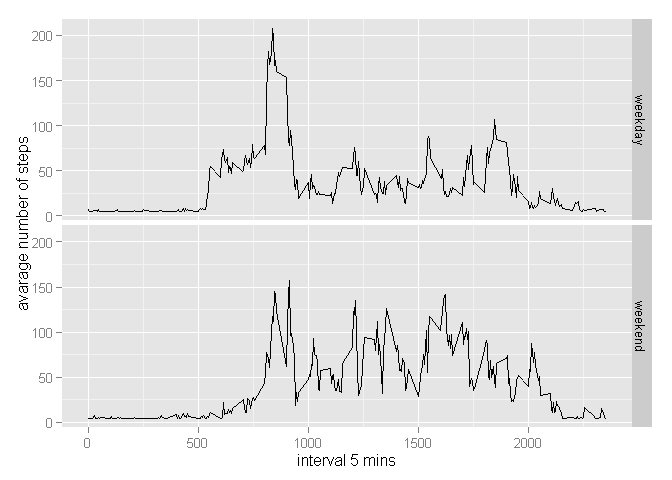

```r
avgactivitiesEnriched <- aggregate(steps ~ interval + dateType,
                                   data=activitiesEnriched,
                                   mean)
ggplot(avgactivitiesEnriched,
       aes(interval, steps)) +
        geom_line() +
        facet_grid(dateType ~ .) +
        xlab("interval 5 mins") +
        ylab("avarage number of steps")
```

Yes there are differences among weekdays and weekends